# NoteCh06 Basic Graphs(基本图形）

AndorZ

2016年5月26日

## 6.1 bar plot条形图

`opar <- par(no.readonly=TRUE)` 在后续的示例中，将使用vcd包分法的Arthritis数据框，故需先安装它：  
`install.packages("vcd")`  
本章用到的其他包：  
`install.packages("plotrix")` `install.packages("sm")` `install.packages("vioplot")` Arthritis数据是探索类风湿性关节炎新疗法研究的结果。  
在关节炎研究中，变量Improved记录了对每位接受了安慰剂或药物治疗的病人的治疗结果

```r
library(vcd)
counts <- table(Arthritis$Improved)
counts
```

```
##
##   None   Some Marked
##     42     14     28
```

28位病人有了明显改善，14人有了部分改善，42人没有改善

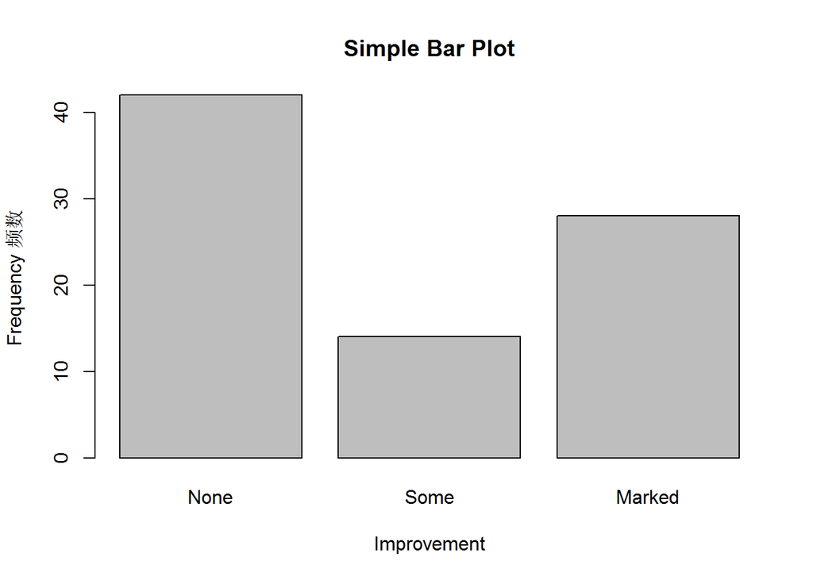

```r
opar <- par(no.readonly=TRUE)
barplot(counts,
        main = "Simple Bar Plot",
        xlab = "Improvement",
        ylab = "Frequency 频数")
```

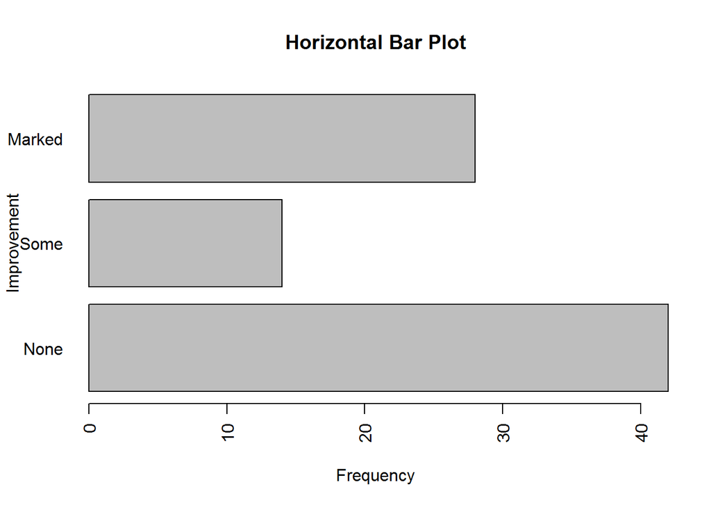

```r
par(las=2)
barplot(counts,
        main = "Horizontal Bar Plot",
        xlab = "Frequency",
        ylab = "Improvement",
        horiz = TRUE)
```

```r
par(opar)
```

### 6.1.2 Stacked and grouped bar plot堆砌条形图和分组条形图

- 治疗类型和改善情况的列联表

```r
two_fre <- table(Arthritis$Improved, Arthritis$Treatment)
two_fre
```

```
##
##          Placebo Treated
##   None        29      13
##   Some         7       7
##   Marked       7      21
```

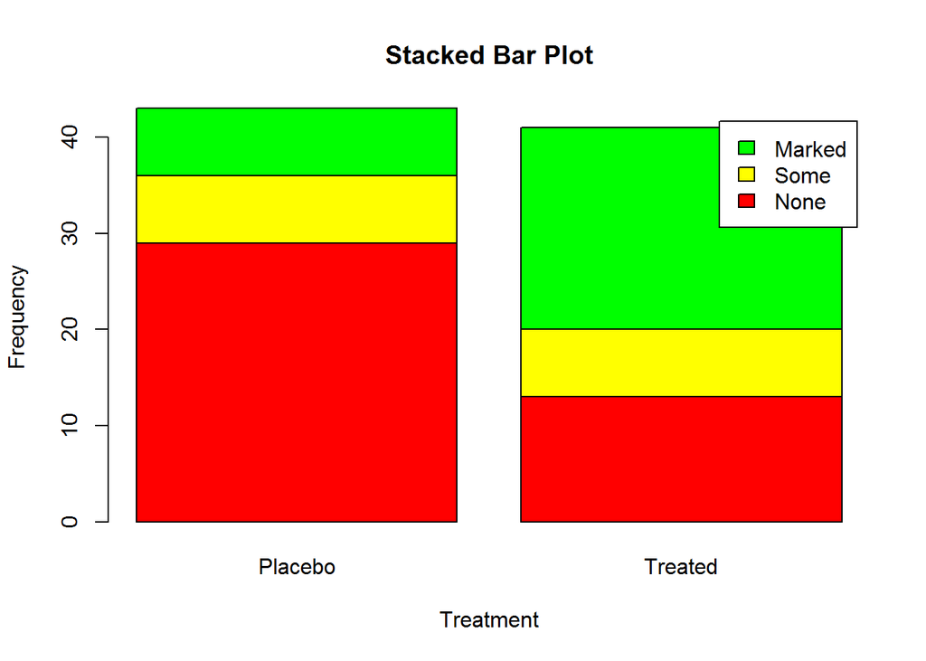

```r
barplot(two_fre,
        main = "Stacked Bar Plot",
        xlab = "Treatment", ylab = "Frequency",
        col = c("red", "yellow", "green"),
        legend=rownames(two_fre)) #beside=FALSE（默认值），堆砌
```

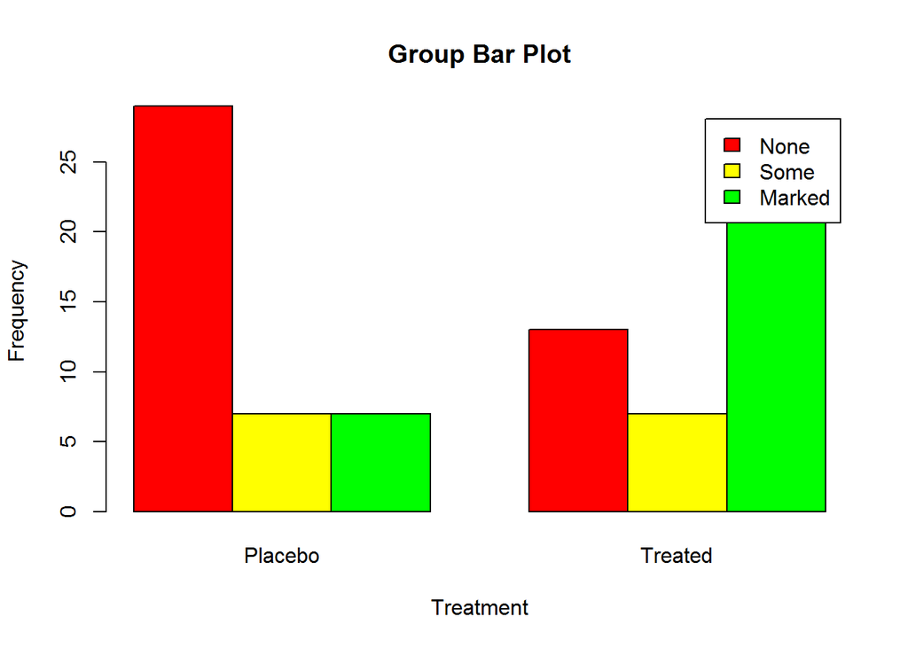

```r
barplot(two_fre,
        main = "Group Bar Plot",
        xlab = "Treatment", ylab = "Frequency",
        col = c("red", "yellow", "green"),
        legend=rownames(two_fre),
        beside = TRUE)  #各列中的值将并列
```

参数legend.text为图例提供了各条形的标签（仅在传入数据为一个矩阵时有用）

### 6.1.3 Bar plot for mean values均值条形图

```r
states <- data.frame(state.region, state.x77)
means <- aggregate(states$Illiteracy, by=list(state.region), FUN=mean)
means
```

```
##         Group.1        x
## 1     Northeast 1.000000
## 2         South 1.737500
## 3 North Central 0.700000
## 4          West 1.023077
```

```r
means <- means[order(means$x),]
means
```

```
##         Group.1        x
## 3 North Central 0.700000
## 1     Northeast 1.000000
## 4          West 1.023077
## 2         South 1.737500
```

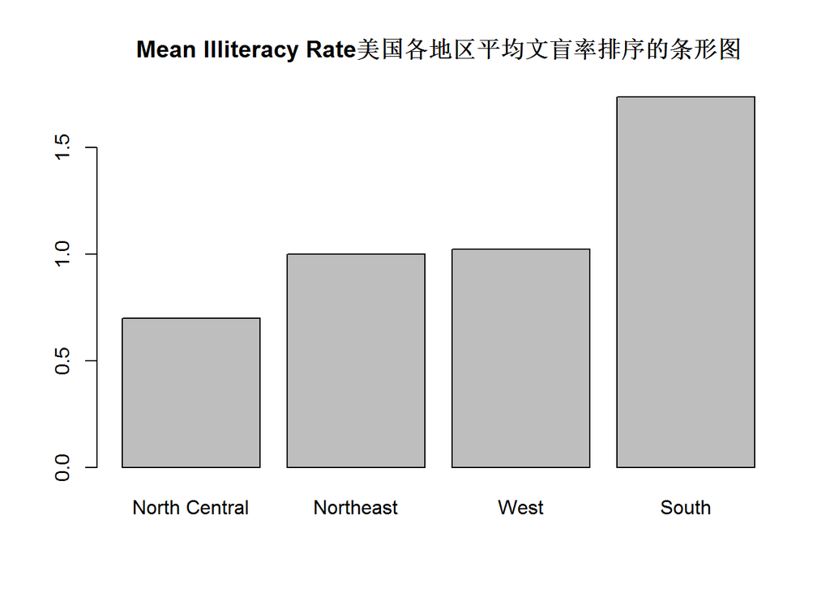

```r
barplot(means$x, names.arg = means$Group.1)
title("Mean Illiteracy Rate美国各地区平均文盲率排序的条形图")
```

可选参数`names.arg`允许指定一个字符向量作为条形的标签名

### 6.1.4 条形图的微调

`cex.names` 字号大小

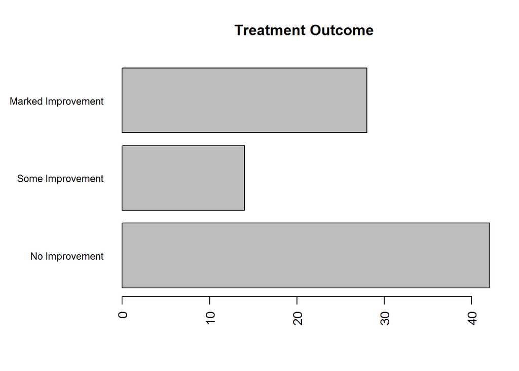

```r
par(mar=c(5, 8, 4, 2)) # 按“下左上右”单位为英分，表示边界的大小。默认值c(5,4,4,2)+0.1
# 增加y边界的大小
par(las=2) # 标签 平行（=0）或者垂直（=2）于坐标轴
counts <- table(Arthritis$Improved)
barplot(counts,
        main = "Treatment Outcome",
        horiz = TRUE,
        cex.names = 0.8,
        names.arg = c("No Improvement", "Some Improvement", "Marked Improvement"))
```

```r
par(opar)
```

### 6.1.5 Spinogram棘状图

Spinogram 对堆砌条形图进行了重缩放，每个条形的高度为1， 每段的高度即表示比例  
由 vcd 包中`spine()`函数绘制

```r
library(vcd)
with(Arthritis,{
  counts <- table(Treatment, Improved);
  spine(counts, main="Spinogram Example")
})
```

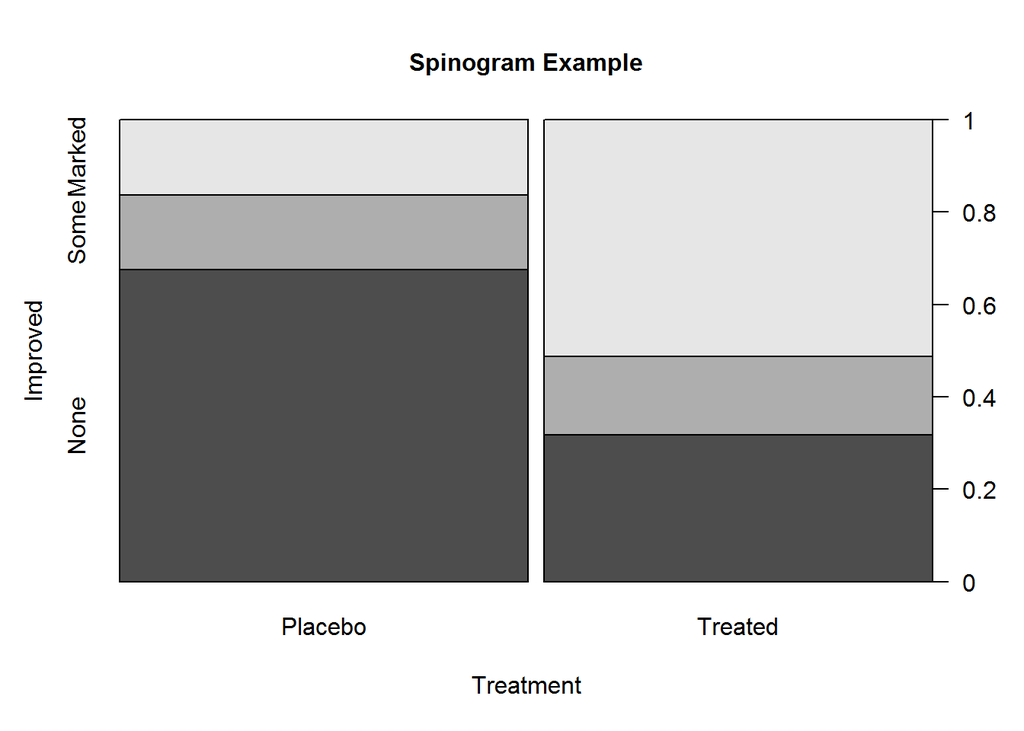

## 6.2 Pie charts饼图

`pie(x, labels)`  
x为非负值向量，表示每个扇形的面积， labels表示各扇形标签的字符型向量

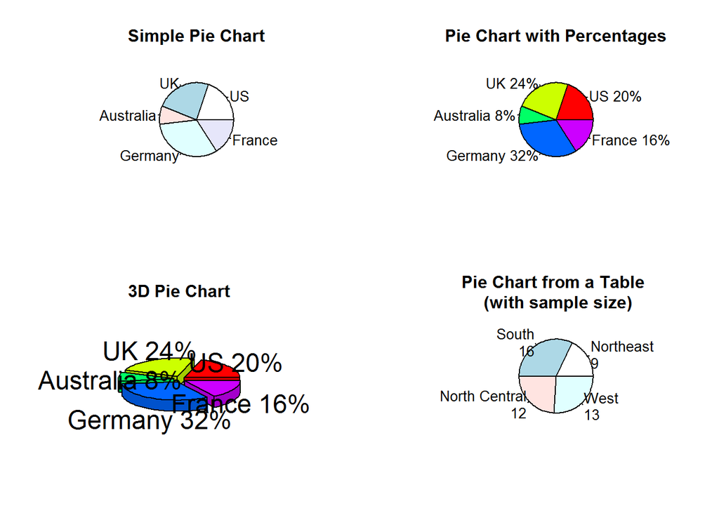

```r
par(mfrow=c(2, 2))  # 2行2列，按行绘图
slices <- c(10, 12, 4, 16, 8)
lbls <- c("US", "UK", "Australia", "Germany", "France")
pie(slices, labels = lbls, main = "Simple Pie Chart")

pct <- round(slices/sum(slices)*100)  #
lbls2 <- paste(lbls, " ", pct, "%", sep = "")
pie(slices, labels = lbls2, col = rainbow(length(lbls2)),
    main = "Pie Chart with Percentages")

library(plotrix)
pie3D(slices, labels = lbls2, explode=0.1, col = rainbow(length(lbls2)),
      main = "3D Pie Chart")

mytable <- table(state.region)
lbls3 <- paste(names(mytable), "\n", mytable, sep="")
pie(mytable, labels = lbls3, main = "Pie Chart from a Table \n (with sample size)")
```

```r
par(opar)
```

- fan plot扇形图

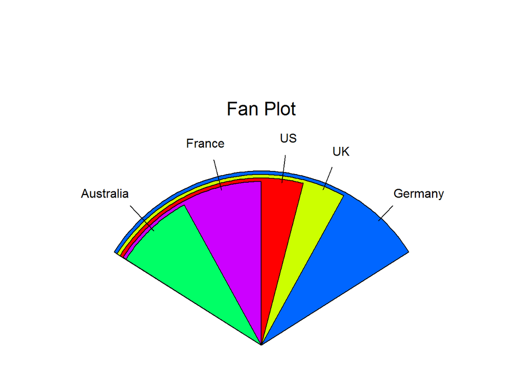

```r
library(plotrix)
slices <- c(10, 12, 4, 16, 8)
lbls <- c("US", "UK", "Australia", "Germany", "France")
fan.plot(slices, labels = lbls, main="Fan Plot")
```

## 6.3 Histograms 直方图

`hist(x)`  
x 数据值组成的数据向量  
参数`freq=FALSE`表示根据概率密度而不是频数绘制  
参数`breaks`用于控制组的数量。  
默认等距切分

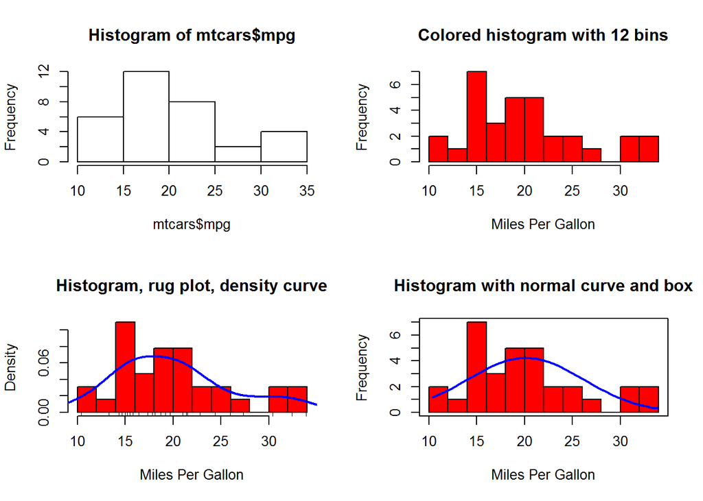

```r
par(mfrow=c(2, 2))

hist(mtcars$mpg)

# 指定组数和颜色
hist(mtcars$mpg, breaks = 12, col = "red", xlab = "Miles Per Gallon",
     main = "Colored histogram with 12 bins")

# 添加轴须图
hist(mtcars$mpg, breaks = 12, col = "red", xlab = "Miles Per Gallon",
     freq = FALSE, main = "Histogram, rug plot, density curve")
rug(jitter(mtcars$mpg))  # 轴须线
lines(density(mtcars$mpg), col="blue", lwd=2)  # 核密度线

# 添加正态密度曲线和外框
x <- mtcars$mpg
h <- hist(x, breaks = 12, col = "red", xlab = "Miles Per Gallon",
          main = "Histogram with normal curve and box")
xfit <- seq(min(x), max(x), length=40)
yfit <- dnorm(xfit, mean = mean(x), sd = sd(x))
yfit <- yfit*diff(h$mids[1:2])*length(x)
lines(xfit, yfit, col="blue", lwd=2)
box()
```

```r
par(opar)
```

## 6.4 Kernel density plot 核密度图

核密度估计：估计随机变量概率密度函数的一种非参数方法。  
核密度图：观察连续型分布的有效方法。  
单独绘制核密度图;  
`plot(density(x))`  
向一副已经存在的图形上叠加一条密度图： `lines(density(x))`

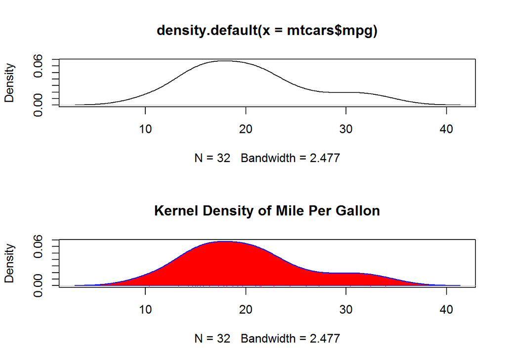

```r
par(mfrow=c(2, 1))
d <- density(mtcars$mpg)
# 创建最简单图形
plot(d)

plot(d, main = "Kernel Density of Mile Per Gallon")
# 将曲线修改为蓝色，并使用实心红色填充曲线下方的区域
polygon(d,col = "red", border = "blue")
rug(mtcars$mpg, col = "brown")  # 轴须线
```

```r
par(opar)
```

polygon()函数根据顶点的x和y坐标绘制多边形

核密度图可用于比较组间差异。 `sm.density.compare()` 函数可向图形叠加多组核密度图。  
`sm.density.compare(x, factor)`  
x 是数值型向量， factor 是一个分组变量。

比较拥有4个、6个、8个气缸车型的每加仑汽油行驶英里数

```r
library(sm)
```

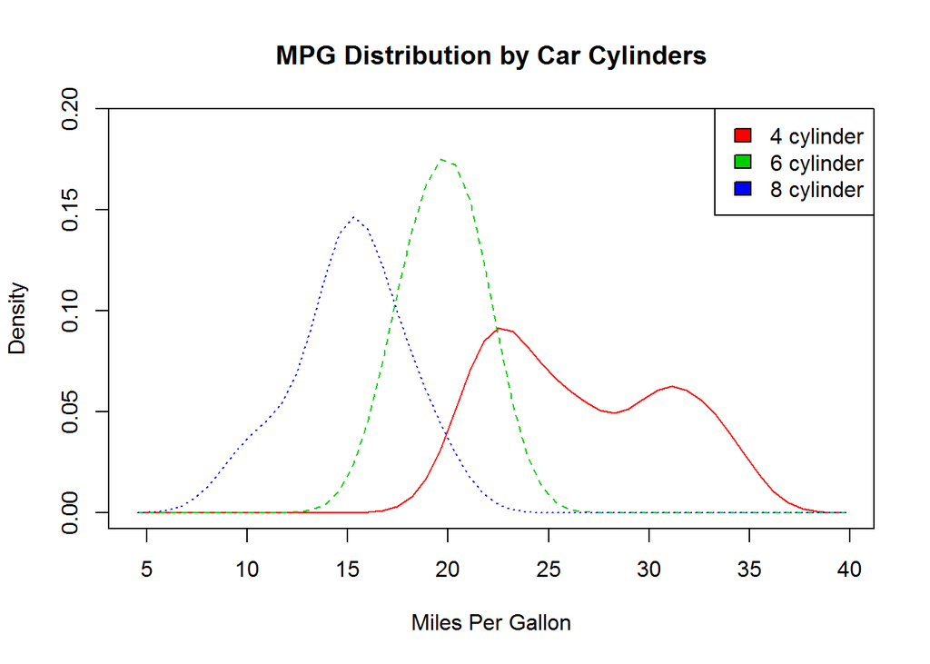

```r
attach(mtcars)

cyl.f <- factor(cyl, levels = c(4, 6, 8),
                labels = c("4 cylinder", "6 cylinder", "8 cylinder"))
sm.density.compare(mpg, cyl, xlab="Miles Per Gallon")
title(main = "MPG Distribution by Car Cylinders")

colfill <- c(2:(1+length(levels(cyl.f))))

#legend(locator(1), levels(cyl.f), fill=colfill) # 通过鼠标单击增加图例
legend("topright", levels(cyl.f), fill=colfill)
```

```r
detach(mtcars)
```

## 6.5 parallel box plots 箱线图

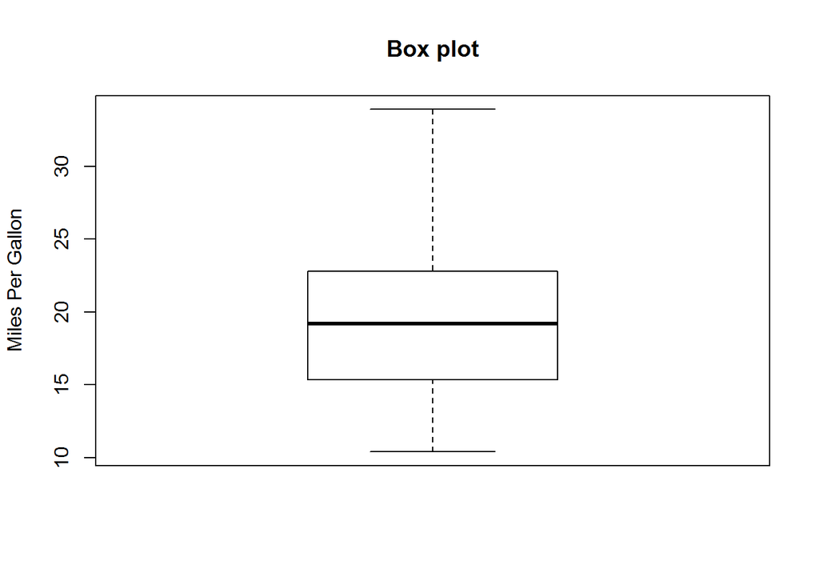

```r
boxplot(mtcars$mpg, main="Box plot", ylab="Miles Per Gallon")
```

两条须的延伸极限不会超过盒型各端加1.5倍四分位距的范围。

### 6.5.1 使用并列箱线图进行夸组比较

`boxplot(formula, data=dataframe)`  
formula 是一个公式，例如公式`Y~A` 将类别型变量A的每个值并列的生成数值型变量Y的箱线图。  
公式`Y~A*B` 则将为类别型变量A和B所有水平的两两组合生成数值型变量的箱线图。  
dataframe 代表提供数据的数据框。  
参数 varwidth=TRUE 是箱线图的**宽度与其样本大小的平方根成正比**。  
参数 horizontal=TRUE 反转坐标轴的方向。 参数 notch=TRUE 绘制含凹槽的箱线图。 ？ 两个箱的凹槽互不重叠，则表明它们的中位数有显著差异。

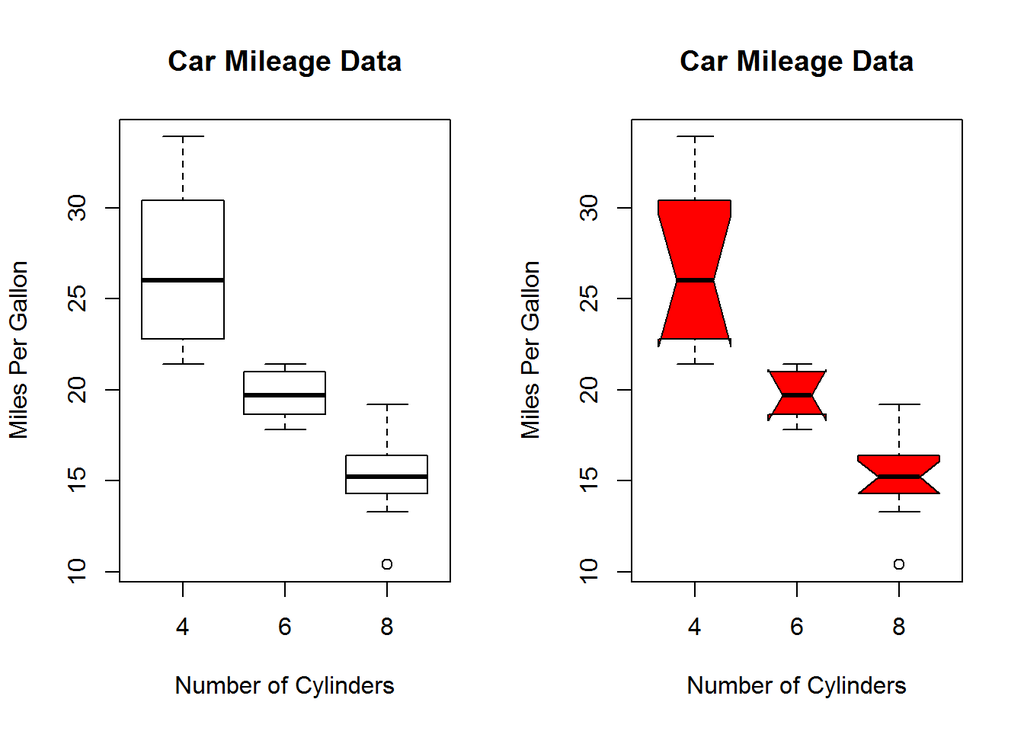

```r
par(mfrow=c(1, 2))
boxplot(mpg~cyl, data = mtcars,
        main = "Car Mileage Data",
        xlab = "Number of Cylinders",
        ylab = "Miles Per Gallon")

# 凹槽箱线图
boxplot(mpg~cyl, data = mtcars,
        notch=TRUE,
        varwidth=TRUE,
        col="red",
        main = "Car Mileage Data",
        xlab = "Number of Cylinders",
        ylab = "Miles Per Gallon")
```

```r
par(opar)
```

可以看到不同组间油耗的区别非常明显。同时也可以发现，六缸车型的每加仑汽油行驶的英里数分布较其他两类车型更为均匀。与六缸和八缸车型相比，四缸车型的每加仑汽油行驶的英里数散布最广（且正偏）。在八缸组还有一个离群点。

直观的理解应该是随着气缸数的增加，每加仑行驶里程数降低。  
也就是书中所说的随着气缸数的减少，有凹明显降低。

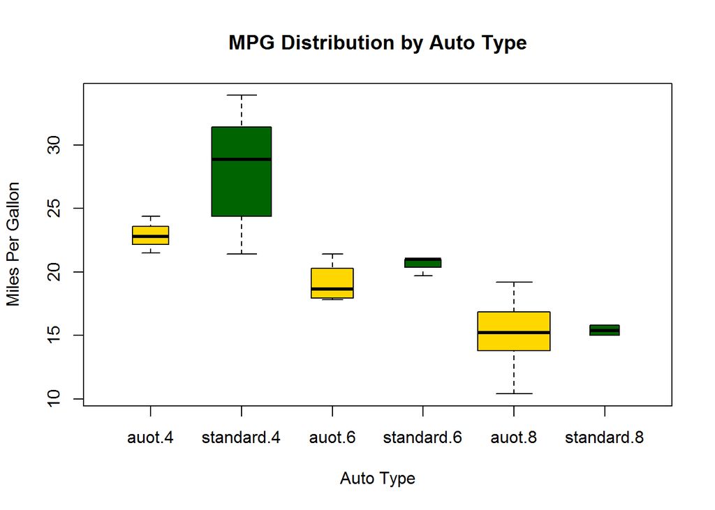

```r
# create a factor for number of cylinders
mtcars$cyl.f <- factor(mtcars$cyl, levels = c(4, 6, 8), labels=c("4", "6","8"))

# create a factor for transmission type 变速箱因子变量
mtcars$am.f <- factor(mtcars$am, levels = c(0, 1), labels = c("auot", "standard"))

# generate boxplot
boxplot(mpg ~ am.f*cyl.f, data=mtcars,
        varwidth=TRUE,
        col = c("gold", "darkgreen"),
        main = "MPG Distribution by Auto Type",
        xlab= "Auto Type", ylab="Miles Per Gallon")
```

### 6.5.2 Vionlin Plots 小提琴图

箱线图与核密度图的结合。 vioplot()函数的使用格式为：  
`vioplot(x1, x2, ..., names= , col= )`  
x1, x2, …表示要绘制的一个或多个数值向量（将为每个向量绘制一幅小提琴图）。  
names是小提琴图中标签的字符向量

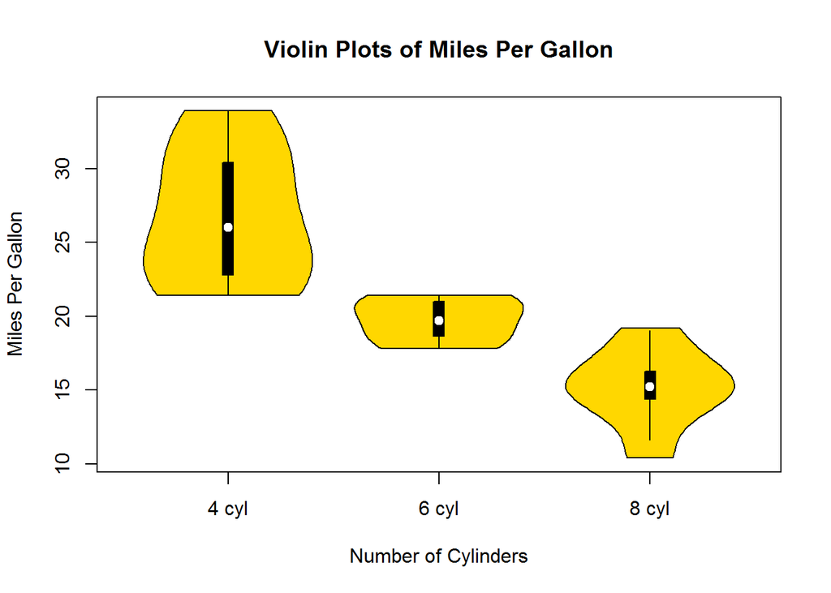

```r
library(vioplot)
x1 <- mtcars$mpg[mtcars$cyl==4]
x2 <- mtcars$mpg[mtcars$cyl==6]
x3 <- mtcars$mpg[mtcars$cyl==8]
vioplot(x1, x2, x3,
        names=c("4 cyl", "6 cyl", "8 cyl"),
        col="gold")
title("Violin Plots of Miles Per Gallon",
      ylab="Miles Per Gallon",xlab="Number of Cylinders")
```

白点是中位数  
黑色盒型的范围是下四分位点到上四分位点  
细黑线表示须。外部形状即为核密度估计。

## 6.6 Dot Plot 点图

`dotchart(x, labels=)`  
x是一个数值向量,labels是由每个点的标签组成的向量

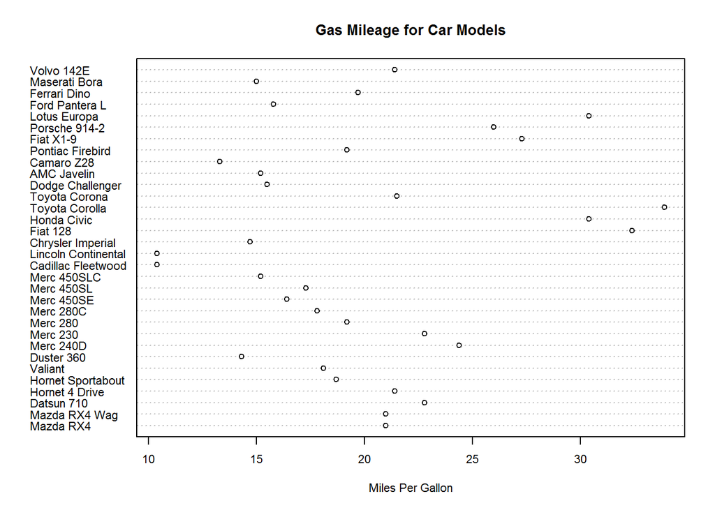

```r
dotchart(mtcars$mpg, labels = row.names(mtcars), cex = .7,
         main = "Gas Mileage for Car Models",
         xlab = "Miles Per Gallon")
```

cex控制标签符号的大小。

通过添加参数**groups**来选定一个因子，用以指定x中元素的分组方式。如果这样做，则参数gcolor可以控制不同组标签的颜色，

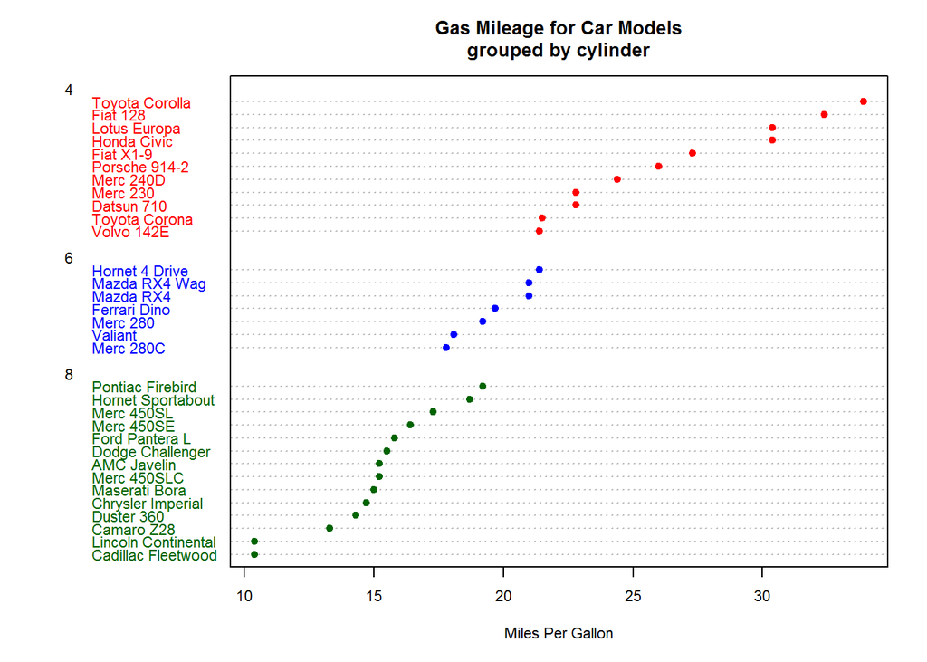

```r
# 根据没加仑行驶英里数升序排列
x <- mtcars[order(mtcars$mpg),]

x$cyl <- factor(x$cyl)
x$color[x$cyl==4] <- "red"
x$color[x$cyl==6] <- "blue"
x$color[x$cyl==8] <- "darkgreen"
dotchart(x$mpg,labels = row.names(x), xlab = "Miles Per Gallon",
         main = "Gas Mileage for Car Models\ngrouped by cylinder",
         cex = .7,pch = 19,
         groups = x$cyl,
         gcolor = "black",
         color = x$color)
```

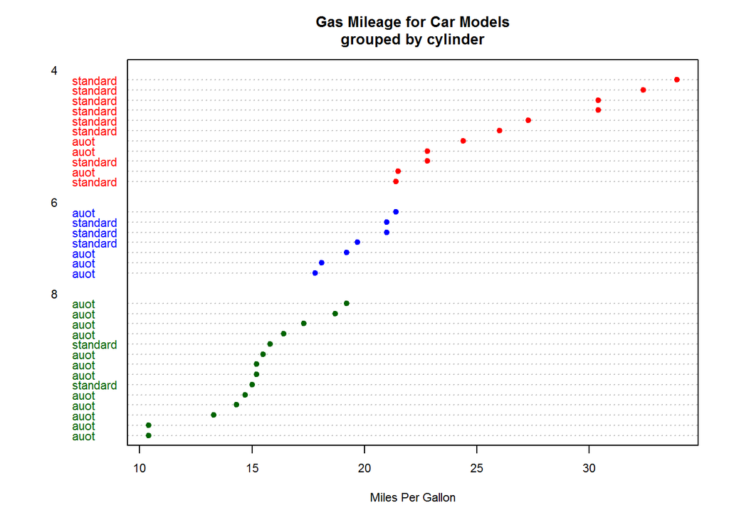

```r
x <- mtcars[order(mtcars$mpg),]
x$am.f <- factor(x$am, levels = c(0, 1), labels = c("auot", "standard"))
x$cyl <- factor(x$cyl)
x$color[x$cyl==4] <- "red"
x$color[x$cyl==6] <- "blue"
x$color[x$cyl==8] <- "darkgreen"
dotchart(x$mpg,labels = x$am.f, xlab = "Miles Per Gallon",
         main = "Gas Mileage for Car Models\ngrouped by cylinder",
         cex = .7,pch = 19,
         groups = x$cyl,
         gcolor = "black",
         color = x$color)
```